# PowerTimePoint_ELIA_provisional

Autogenerated data summary from dataMaid

2024-02-08 17:55:45.895168

# Data report overview

The dataset examined has the following dimensions:

| Feature | Result |
| --- | --- |
| Number of observations | 5 |
| Number of variables | 4 |

### Checks performed

The following variable checks were performed, depending on the data type of each variable:

|  | character | factor | labelled | haven labelled | numeric | integer | logical | Date |
| --- | --- | --- | --- | --- | --- | --- | --- | --- |
| Identify miscoded missing values | × | × | × | × | × | × |  | × |
| Identify prefixed and suffixed whitespace | × | × | × | × |  |  |  |  |
| Identify levels with < 6 obs. | × | × | × | × |  |  |  |  |
| Identify case issues | × | × | × | × |  |  |  |  |
| Identify misclassified numeric or integer variables | × | × | × | × |  |  |  |  |
| Identify outliers |  |  |  |  | × | × |  | × |

Please note that all numerical values in the following have been rounded to 2 decimals.

# Summary table

|  | Variable class | # unique values | Missing observations | Any problems? |
| --- | --- | --- | --- | --- |
| PowerTimePoint.atTime | POSIXct | 2 | 0.00 % | × |
| PowerTimePoint.activatedP | numeric | 3 | 0.00 % | × |
| PowerTimePoint.activatedPrice | numeric | 5 | 0.00 % | × |
| PowerTimePoint.PowerSchedule | character | 1 | 0.00 % | × |

# Variable list

## PowerTimePoint.atTime

- The variable has class POSIXct which is not supported by dataMaid.

## PowerTimePoint.activatedP

- Note that this variable is treated as a factor variable below, as it only takes a few unique values.

| Feature | Result |
| --- | --- |
| Variable type | numeric |
| Number of missing obs. | 0 (0 %) |
| Number of unique values | 3 |
| Mode | “-5” |
| Reference category | -5 |

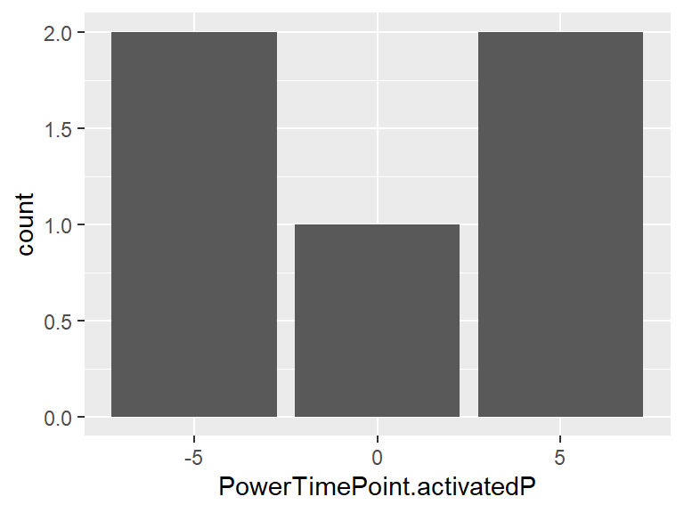

- Note that the following levels have at most five observations: "-5", "0", "5".

## PowerTimePoint.activatedPrice

- Note that this variable is treated as a factor variable below, as it only takes a few unique values.

| Feature | Result |
| --- | --- |
| Variable type | numeric |
| Number of missing obs. | 0 (0 %) |
| Number of unique values | 5 |
| Mode | “-35” |
| Reference category | -35 |

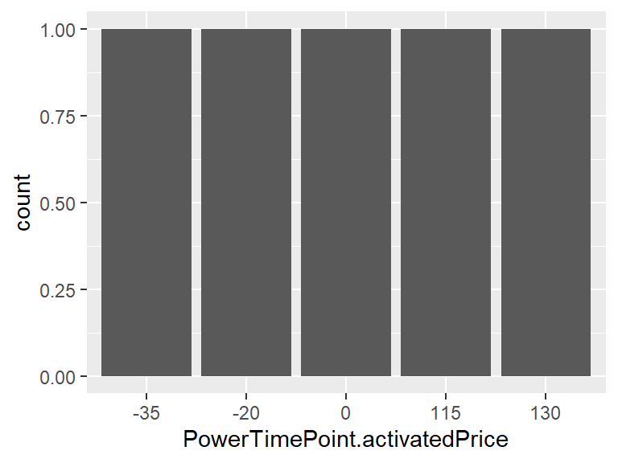

- Note that the following levels have at most five observations: "-20", "-35", "0", "115", "130".

## PowerTimePoint.PowerSchedule

- The variable only takes one (non-missing) value: "". The variable contains 0 % missing observations.

Report generation information:

- Created by: Excel-kaeyros-237 (username: `LENOVO`).
- Report creation time: jeu. févr. 08 2024 17:55:46
- Report was run from directory: `C:/R project/data-catalogue`
- dataMaid v1.4.1 [Pkg: 2021-10-08 from RSPM (R 4.3.0)]
- R version 4.3.2 (2023-10-31 ucrt).
- Platform: x86_64-w64-mingw32/x64 (64-bit)(Africa/Lagos).
- Function call: `dataMaid::makeDataReport(data = get(rds_files_no_extension[i]), output = "html", file = paste(path, rds_files_no_extension[i]), replace = TRUE, openResult = FALSE, reportTitle = rds_files_no_extension[i])`